# GET00203 - Estatística Computacional 1

Aula 07 - Propriedades dos estimadores: vício, consistência e eficiência

[Rafael Erbisti](https://sites.google.com/site/rerbisti)

### Ilustrando propriedades de estimadores

#### Tendência ou viés

Definimos o viés ou vício ou tendência de um estimador $T$ de $\theta$ como sendo
$$\text{Viés}(T) = E[T] - \theta.$$
Em particular, se $E[T] = \theta$, ou seja, se o viés de $T$ é nulo, dizemos que $T$ é um estimador não-viesado (ou não-tendencioso) de $\theta$; caso contrário, $T$ é dito viesado (ou tendencioso).

Vamos ilustrar dois estimadores para a variância de uma população:
$$\hat{\sigma}^2 = \frac{\sum_{i=1}^{n} (X_i - \bar{X})^2}{n} \quad
\text{e} \quad S^2 = \frac{\sum_{i=1}^{n} (X_i - \bar{X})^2}{n-1}.$$
Pela teoria de Inferência Estatística, sabemos que o primeiro estimador é viesado para estimar a variância populacional. Vamos, por meio de simulação, comparar os estimadores em pequenas amostras.

- **Simulação:** gerar 1000 amostras de tamanho 10 de uma distribuição normal com média 5 e desvio padrão 2.
- **Estimadores:** o primeiro estimador (viesado) utiliza $\hat{\sigma}^2$. O segundo estimador (não viesado) utiliza $S^2$.
- **Visualização:** comparar a distribuição dos dois estimadores e uma linha vertical vermelha marcando a variância verdadeira $\sigma^2=4$.

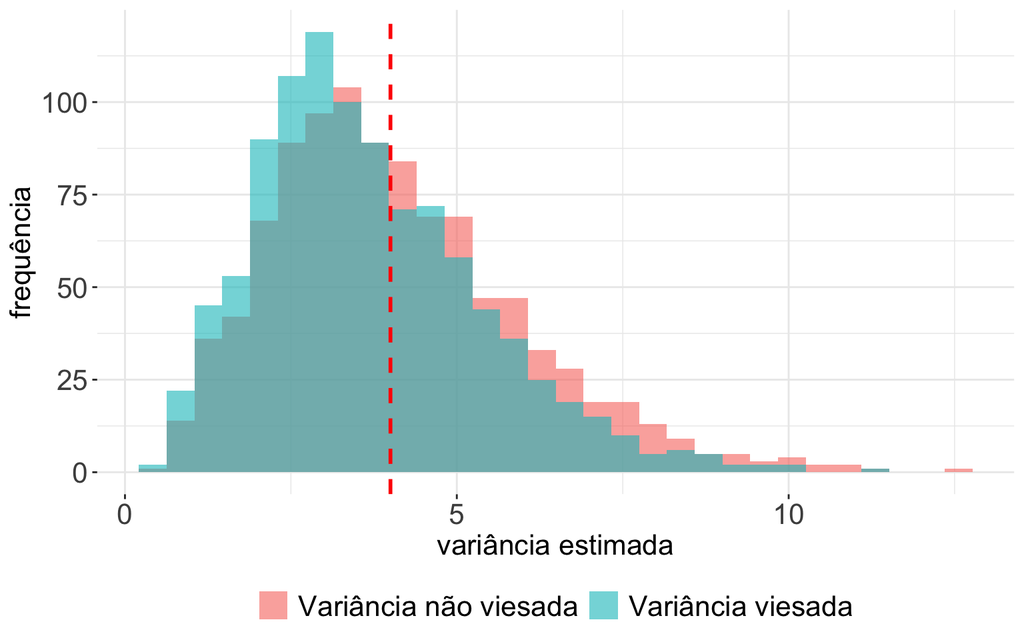

```r
# Parâmetros da simulação
set.seed(1)  # Para reprodutibilidade
n = 10  # Tamanho da amostra
mu = 5  # Média populacional
sigma = 2  # Desvio padrão populacional
n_simula = 1000  # Número de simulações

# Função para calcular os dois estimadores de variância
simula_variancias = function(n, mu, sigma, n_simula) {
  var_viesada = numeric(n_simula)
  var_nviesada = numeric(n_simula)

  for (i in 1:n_simula) {
    amostra = rnorm(n, mean = mu, sd = sigma)
    # Estimador viesado
    var_viesada[i] = sum((amostra - mean(amostra))^2) / n
    # Estimador não viesado
    var_nviesada[i] = sum((amostra - mean(amostra))^2) / (n - 1)
  }

  tibble(
    Simulação = 1:n_simula,
    `Variância viesada` = var_viesada,
    `Variância não viesada` = var_nviesada
  )
}

# Gerar os dados de variâncias
var_data = simula_variancias(n, mu, sigma, n_simula)

# Transformação dos dados para visualização
var_melt = var_data |>
  pivot_longer(cols = 2:3,
               names_to = 'Estimador',
               values_to = 'Variância')

# Visualização
ggplot(var_melt, aes(x = Variância, fill = Estimador)) +
  geom_histogram(alpha = 0.6, position = "identity", bins = 30) +
  geom_vline(xintercept = sigma^2, color = "red", linetype = "dashed", size = 1) +
  labs(x = "variância estimada", y = "frequência") +
  theme_bw() +
  theme(legend.title = element_blank(),
        legend.position = "bottom",
        legend.text = element_text(size = 16),
        axis.text.x = element_text(size = 16),
        axis.title.x = element_text(size = 16),
        axis.text.y = element_text(size = 16),
        axis.title.y = element_text(size = 16),
        panel.border = element_blank())
```

#### Consistência

Um estimador é consistente se, à medida que o tamanho da amostra aumenta, ele converge para o valor verdadeiro do parâmetro.

Para ilustrar a propriedade de **consistência** de um estimador, podemos usar a média amostral.

A média amostral é utilizada como o estimador da média populacional $\mu$ e é dada por:
$$\bar{X} = \frac{1}{n} \sum_{i=1}^{n} X_i$$
onde:

- $\bar{X}$ é a média amostral
- $X_i$ são as observações da amostra
- $n$ é o tamanho da amostra.

Neste caso, a média amostral $\bar{X}$ deve convergir para a média populacional $\mu$,
$$\lim_{n \to \infty} \bar{X} = \mu$$
Ou seja, para amostras grandes, a média amostral $\bar{X}$ tende a se aproximar de $\mu$, o que caracteriza a propriedade de consistência do estimador.

Na simulação abaixo, as amostras são extraídas de uma distribuição normal com média $\mu$ e desvio padrão $\sigma$, isto é,
$$X_i \sim N(\mu, \sigma^2)$$
onde:

- $\mu$ é a média da distribuição (neste caso, $\mu = 5$)
- $\sigma^2$ é a variância da distribuição (neste caso, $\sigma = 2$).

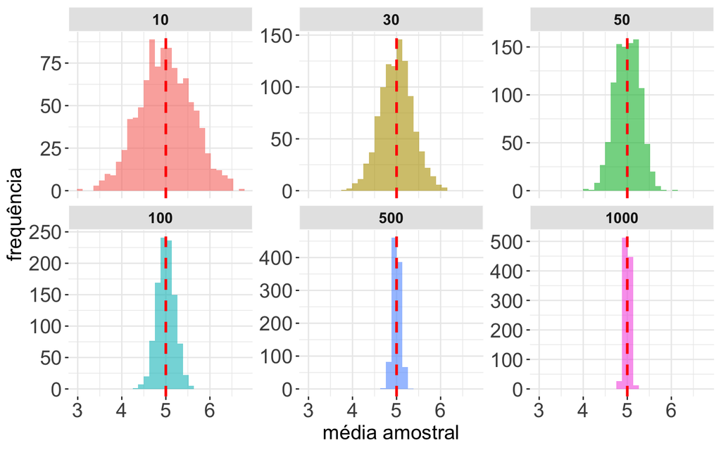

```r
# Parâmetros da simulação
mu = 5        # Média populacional
sigma = 2     # Desvio padrão populacional
n_simulations = 1000  # Número de simulações
n_samples = c(10, 30, 50, 100, 500, 1000)  # Diferentes tamanhos de amostra

# Função para simular médias amostrais para diferentes tamanhos de amostra
simulate_means = function(n_samples, mu, sigma, n_simulations) {
  data = tibble()

  for (n in n_samples) {
    means = numeric(n_simulations)
    for (i in 1:n_simulations) {
      sample = rnorm(n, mean = mu, sd = sigma)
      means[i] = mean(sample)
    }
    data = rbind(data, tibble(Tamanho_Amostra = rep(n, n_simulations),
                              Media_Amostral = means))
  }
  return(data)
}

# Gerar os dados de médias amostrais
means_data <- simulate_means(n_samples, mu, sigma, n_simulations)

# Visualização com ggplot2
ggplot(means_data, aes(x = Media_Amostral, fill = factor(Tamanho_Amostra))) +
  geom_histogram(alpha = 0.6, position = "identity", bins = 30) +
  geom_vline(xintercept = mu, color = "red", linetype = "dashed", size = 1) +
  labs(x = "média amostral", y = "frequência") +
  facet_wrap(~ Tamanho_Amostra, scales = "free_y") +
  theme_bw() +
  theme(legend.position = "none",
        axis.text.x = element_text(size = 16),
        axis.title.x = element_text(size = 16),
        axis.text.y = element_text(size = 16),
        axis.title.y = element_text(size = 16),
        panel.border = element_blank(),
        strip.background = element_rect(fill="gray90",colour = "white"),
        strip.text = element_text(face = "bold", size = 12))
```

#### Eficiência

Para avaliar a eficiência de um estimador, comparamos a variância de diferentes estimadores que são não tendenciosos (sem viés). **O estimador mais eficiente é aquele que possui menor variância**.

Na simulação abaixo, comparamos a variância de quatro estimadores diferentes para a média de uma população $N(\mu,\sigma^2)$ a partir de amostras de tamanhos variados.

Os estimadores para a média populacional não viesados utilizados na simulação são:

- **Média amostral**
  $$\bar{X} = \frac{1}{n} \sum_{i=1}^{n} X_i$$
- **Mediana amostral**
  $$\tilde{X} = \text{mediana}(X_1, X_2, \dots, X_n)$$
- **Média do Mínimo e Máximo**
  $$\bar{X}^* = \frac{X_{\text{min}} + X_{\text{max}}}{2}$$
  onde $X_{\text{min}}$ e $X_{\text{max}}$ são os valores mínimo e máximo da amostra, respectivamente.
- **Moda amostral**
  $$\text{Moda}(X) = \max \text{freq}(X_i)$$
  onde a moda é o valor mais frequente da amostra $X_1, X_2, \ldots, X_n$.

A **eficiência** pode ser medida comparando a variância de dois estimadores. Por exemplo, sejam dois estimadores $T_1$ e $T_2$, ambos não tendenciosos, onde o estimador $T_1$ é considerado mais eficiente do que $T_2$ se
$$\dfrac{\textrm{Var}(T_1)}{\textrm{Var}(T_2)}<1$$
Neste caso, $T_1$ seria considerado mais eficiente que $T_2$. Na simulação abaixo, foram geradas amostras de diferentes tamanhos de uma distribuição normal $N(5,4)$. Para cada amostra, calculamos os 4 estimadores listados acima, repetindo o processo 1000 vezes para cada tamanho de amostra.

O gráfico mostra a distribuição das estimativas de cada estimados da lista acima (média, mediana, média entre máximo e mínimo, e a moda) para diferentes tamanhos de amostra. Uma linha vertical vermelha marca o valor verdadeiro da média $(\mu=5)$.

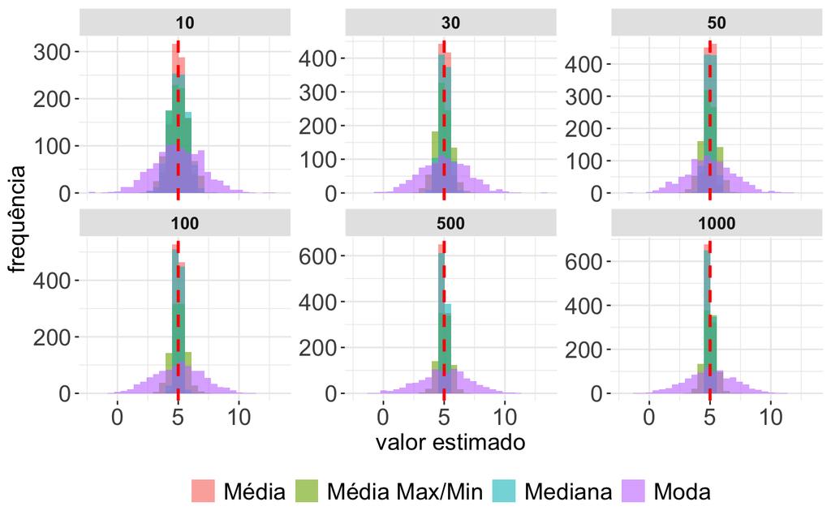

```r
# Função para calcular a moda
mode_estimator = function(x){
  uniq_vals = unique(x)
  uniq_vals[which.max(tabulate(match(x, uniq_vals)))]}

# Função para calcular a média do máximo e mínimo
max_min_mean = function(x) {
  (min(x) + max(x)) / 2}

# Parâmetros da simulação
mu = 5        # Média populacional
sigma = 2     # Desvio padrão populacional
n_simulations = 1000  # Número de simulações
n_samples = c(10, 30, 50, 100, 500, 1000)  # Diferentes tamanhos de amostra

# Função para simular estimadores para diferentes tamanhos de amostra
simulate_estimators = function(n_samples, mu, sigma, n_simulations) {
  data = tibble()

  for (n in n_samples) {
    means = numeric(n_simulations)
    medians = numeric(n_simulations)
    max_min_means = numeric(n_simulations)
    modes = numeric(n_simulations)

    for (i in 1:n_simulations) {
      sample = rnorm(n, mean = mu, sd = sigma)

      means[i] = mean(sample)  # Média
      medians[i] = median(sample)  # Mediana
      max_min_means[i] = max_min_mean(sample)  # Média do máximo e mínimo
      modes[i] = mode_estimator(sample)  # Moda
    }

    data = rbind(data, data.frame(
      Tamanho_Amostra = rep(n, 4 * n_simulations),
      Estimador = rep(c("Média", "Mediana", "Média Max/Min", "Moda"), each = n_simulations),
      Valor = c(means, medians, max_min_means, modes)
    ))
  }

  return(data)
}

# Gerar os dados dos quatro estimadores
estimators_data = simulate_estimators(n_samples, mu, sigma, n_simulations)

# Visualização
ggplot(estimators_data, aes(x = Valor, fill = Estimador)) +
  geom_histogram(alpha = 0.6, position = "identity", bins = 30) +
  geom_vline(xintercept = mu, color = "red", linetype = "dashed", size = 1) +
  facet_wrap(~ Tamanho_Amostra, scales = "free_y") +
  labs(x = "valor estimado", y = "frequência") +
  theme_bw() +
  theme(legend.title = element_blank(),
        legend.position = "bottom",
        legend.text = element_text(size = 16),
        axis.text.x = element_text(size = 16),
        axis.title.x = element_text(size = 16),
        axis.text.y = element_text(size = 16),
        axis.title.y = element_text(size = 16),
        panel.border = element_blank(),
        strip.background = element_rect(fill="gray90",colour = "white"),
        strip.text = element_text(face = "bold", size = 12))
```

A comparação visual acima permite ver como a variância da média amostral é menor do que a da moda amostral, demonstrando que a média é um estimador mais eficiente para amostras de distribuições normais. Entretanto, a visualização não deixa muito clara a diferença da variância entre os estimadores da mediana amostral e da média entre o máximo e mínimo amostrais.

Para isso, calcularemos as variâncias estimadas de cada estimador, avaliando a eficiência de cada um em comparação à média amostral.

```r
# Função para simular estimadores para diferentes tamanhos de amostra
simulate_estimators = function(n_samples, mu, sigma, n_simulations) {
  variances = tibble(Tamanho_Amostra = integer(), Estimador = character(), Variancia = numeric())

  for (n in n_samples) {
    means = numeric(n_simulations)
    medians = numeric(n_simulations)
    max_min_means = numeric(n_simulations)

    for (i in 1:n_simulations) {
      sample = rnorm(n, mean = mu, sd = sigma)

      means[i] = mean(sample)  # Média
      medians[i] = median(sample)  # Mediana
      max_min_means[i] = max_min_mean(sample)  # Média do máximo e mínimo
    }

    # Calcular variâncias
    variances = rbind(variances, data.frame(Tamanho_Amostra = n, Estimador = "Média", Variancia = var(means)))
    variances = rbind(variances, data.frame(Tamanho_Amostra = n, Estimador = "Mediana", Variancia = var(medians)))
    variances = rbind(variances, data.frame(Tamanho_Amostra = n, Estimador = "Média Max/Min", Variancia = var(max_min_means)))
  }

  return(variances)
}

# Gerar variâncias dos estimadores
variances_data = simulate_estimators(n_samples, mu, sigma, n_simulations)

# Visualizar variâncias
print(variances_data)
```

```
   Tamanho_Amostra     Estimador   Variancia
1               10         Média 0.384818130
2               10       Mediana 0.529238573
3               10 Média Max/Min 0.710716657
4               30         Média 0.135799208
5               30       Mediana 0.211482705
6               30 Média Max/Min 0.454593118
7               50         Média 0.077963062
8               50       Mediana 0.125662866
9               50 Média Max/Min 0.412895648
10             100         Média 0.042866469
11             100       Mediana 0.064033453
12             100 Média Max/Min 0.394409086
13             500         Média 0.008460834
14             500       Mediana 0.013362529
15             500 Média Max/Min 0.289633954
16            1000         Média 0.003907976
17            1000       Mediana 0.006555914
18            1000 Média Max/Min 0.227407949
```

```r
# Calcular as razões de variância em relação à média amostral
compare_variances = function(variances_data) {
  ratio_data = tibble(Tamanho_Amostra = integer(), Estimador = character(), Razao_Variancia = numeric())

  for (n in n_samples) {
    var_mean = variances_data$Variancia[variances_data$Tamanho_Amostra == n & variances_data$Estimador == "Média"]

    for (est in c("Mediana", "Média Max/Min")) {
      var_other = variances_data$Variancia[variances_data$Tamanho_Amostra == n & variances_data$Estimador == est]
      ratio_data = rbind(ratio_data, data.frame(Tamanho_Amostra = n, Estimador = est, Razao_Variancia = var_other / var_mean))
    }
  }

  return(ratio_data)
}

# Gerar as razões de variâncias
variance_ratios = compare_variances(variances_data)

# Visualizar as razões de variância
print(variance_ratios)
```

```
   Tamanho_Amostra     Estimador Razao_Variancia
1               10       Mediana        1.375295
2               10 Média Max/Min        1.846890
3               30       Mediana        1.557319
4               30 Média Max/Min        3.347539
5               50       Mediana        1.611826
6               50 Média Max/Min        5.296042
7              100       Mediana        1.493789
8              100 Média Max/Min        9.200876
9              500       Mediana        1.579339
10             500 Média Max/Min       34.232316
11            1000       Mediana        1.677573
12            1000 Média Max/Min       58.190727
```

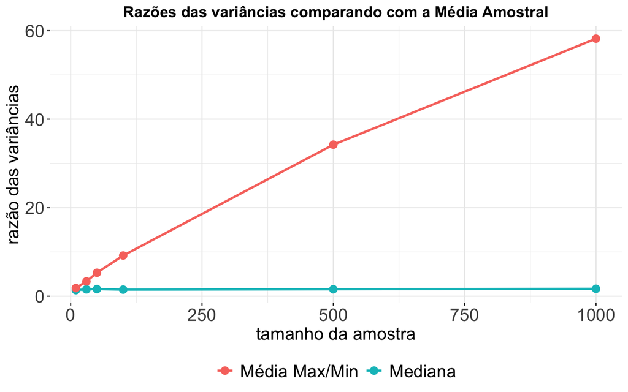

```r
# Gráfico para comparar as razões de variância
ggplot(variance_ratios, aes(x = Tamanho_Amostra, y = Razao_Variancia, color = Estimador)) +
  geom_line(size = 1) +
  geom_point(size = 3) +
  labs(title = "Razões das variâncias comparando com a Média Amostral",
       x = "tamanho da amostra", y = "razão das variâncias") +
  theme_bw() +
  theme(plot.title = element_text(size = 14, face = "bold", hjust = 0.5),
        legend.title = element_blank(),
        legend.position = "bottom",
        legend.text = element_text(size = 16),
        axis.text.x = element_text(size = 16),
        axis.title.x = element_text(size = 16),
        axis.text.y = element_text(size = 16),
        axis.title.y = element_text(size = 16),
        panel.border = element_blank())
```

> **Desafio:** Verifique, por meio de simulação, se o estimador $\hat{\lambda} = 1/\bar{X}$ é um estimador consistente para o parâmetro $\lambda$ da distribuição exponencial $f(x)=\lambda \exp\{-\lambda x \}, \ x>0$. Justifique sua resposta através de um gráfico, comentando-o. (Utilize $n = 2, 5, 10, 50, 100, 200, 500$.) .